# MATH5741M: Statistical Theory and Methods

Benjamin Thorpe

2021-10-29

Benjamin Thorpe (b.thorpe@leeds.ac.uk)  
Friday October 29, 2021

# 5 Inference

We have seen that an estimate is just a single realisation of a random statistic. We therefore understand that different samples will produce different estimates of the same underlying parameter. Uncertainty is an unavoidable feature of parameter estimation. How can we properly address this when we present the findings of a statistical analysis?

Anyone who spends even a brief time reading scientific literature is likely to come across the concepts of statistical significance testing and confidence intervals. For example, recall our globular clusters example. Suppose that we observe a random sample of $n = 100$ galaxies and estimate a rate of $500$ clusters per galaxy based on our sample. Does this give us strong enough evidence to confidently reject possibility that the actual rate across the observable universe is $1000$ clusters per galaxy? What about $10^6$ clusters per galaxy? As we will learn in this chapter, we could attempt to answer these questions by carrying out a significance test. Even better, we could calculate a confidence interval, which would contain all of the possible values of this unknown rate that we are unwilling to reject.

In medical research, confidence intervals are recommended in guidelines for reporting clinical trials (http://www.consort-statement.org), observational studies (http://www.strobe-statement.org) and meta-analyses (http://www.prisma-statement.org). This makes sense because presenting just an estimate might misrepresent our results by suggesting that we are absolutely sure that this estimate is equal to the true value of the parameter. A confidence interval instead gives a range of plausible values for the parameter and therefore gives the reader some idea of the amount of uncertainty in our estimate.

But claims based on significance testing are controversial, frequently misunderstood and sometimes badly misused. One issue is the overuse of arbitrary thresholds, including phrases such as “$95\%$ confidence” and “significant at the $5\%$ level”. Researchers sometimes use claims of statistical significance (especially the phrase “$p < 0.05$”) as a substitute for careful interpretation of their results. Readers of journal articles can mistakenly interpret statistical significance as proof of practical significance, especially if authors fail to properly emphasise the difference between the two. Even medical journals are guilty of publication bias, since statistically significant results are more likely to be published, thus creating the illusion that some treatments are more effective than they actually are.

There are alternatives to confidence intervals and significance tests (as we will see when we study Bayesian inference). But confidence intervals, p-values, and other ideas based on statistical significance are highly prevalent in scientific literature, so we are unable to avoid them or dismiss them. Instead, we should learn to interpret them cautiously.

Over the next few lectures, we will learn how to devise significance tests, how to construct confidence intervals, and how to sensibly interpret our results. This will rely on ideas from previous sections, especially our understanding of estimators as random quantities with their own sampling distributions.

## 5.1 Central limit theorem

If we want to understand the uncertainty in our estimates, we need some knowledge of the sampling distribution of the estimator. Usually, this comes from our knowledge of the distribution from which our random sample is taken.

**Example 5.1 (quality of life)** Health economists sometimes measure quality of life on a scale of $0$ (death) to $100$ (perfect health).[^1] Suppose that a new drug is believed to increase quality of life in chronic obstructive pulmonary disease (COPD) patients. Suppose that:

- The random variable $X$ denotes quality of life for a random COPD patient who uses the drug.
- We are **not** willing to assume a specific distribution for $X$.
- $\text{var}(X) = \sigma^2 = 100$ is **known**.
- ${\mathsf E}(X) = \mu$ is **unknown**.

A study will be performed by taking a random sample of $n = 25$ COPD patients who use the drug. The population mean $\mu$ will be estimated by calculating the sample mean,
$$\widehat{\mu} = \overline{x}.$$
How likely are we to observe an estimate within $4$ points of the true value of $\mu$? In other words, thinking of the sample mean as a random estimator,
$$\widehat{\mu} = \overline{X},$$
what is the probability
$${\mathsf P}(-4 < \overline{X} - \mu < 4)\;?$$
This seems like an impossible question to answer. How can we possibly calculate this probability without assuming a distribution for $X$? How can we calculate it if we don’t even know $\mu$?

**Theorem 5.1 (Central Limit Theorem (CLT))** Let $X_1,X_2,\ldots, X_{n}$ be an IID sample from a distribution with expectation $\mu$ and variance $\sigma^2$. Then the approximate distribution of the sample mean is
$$\overline{X}\;\; \stackrel{\text{approx.}}{\sim} \;\;\text{N}\left(\mu, \frac{\sigma^2}{n}\right)$$
when $n$ is large.[^2]

In other words, no matter what distribution our sample is drawn from (whether discrete or continuous, skewed or symmetrical, etc.), we know that the distribution of the sample mean will be approximately normal if the sample is large enough. We can then use this to calculate probabilities.

Rearranging, this is equivalent to
$$\frac{\overline{X} - \mu}{\sqrt{{\sigma^2}/{n}}}\;\; \stackrel{\text{approx.}}{\sim} \;\;\text{N}\left(0, 1\right),$$
which is more helpful in practice, since we can read probabilities for $\text{N}\left(0, 1\right)$ from the standard normal distribution tables.

**Theorem 5.2** If the sample is from a normal distribution, $X_{1}, \ldots, X_{n} \sim N(\mu, \sigma^2)$, then the sampling distribution given in the CLT is **exact** for **any** $n$ (not just approximate, not just for large $n$).

**Solution to Example 5.1.** The CLT tells us that
$$\frac{\overline{X} - \mu}{\sqrt{{100}/{25}}}\;\; =\;\; \frac{\overline{X} - \mu}{2} \;\; \stackrel{\text{approx.}}{\sim} \;\;\text{N}\left(0, 1\right).$$
We want to know the probability
$$\begin{eqnarray*}
{\mathsf P}(-4 < \overline{X} - \mu < 4) & = & {\mathsf P}\left(-\frac{4}{2} < \frac{\overline{X} - \mu}{2} < \frac{4}{2}\right) \\
& \approx & {\mathsf P}\left(-2< Z < 2\right)
\end{eqnarray*}$$
where $Z \sim N(0, 1)$. Then we can write
$$\begin{eqnarray*}
{\mathsf P}\left(-2< Z < 2\right) & = & {\mathsf P}\left(-2< Z \text{ and } Z < 2\right)\\
& = & {\mathsf P}\left(Z < 2\right) - {\mathsf P}\left( -2 \geq Z\right).
\end{eqnarray*}$$
Letting $\Phi(z)$ denote the CDF of a standard normal variable, we have
$${\mathsf P}\left(Z < 2\right) = \Phi(2) \approx 0.977,$$
from either the normal distribution tables or from `pnorm(2)` in R. By symmetry of the normal distribution,
$$\begin{eqnarray*}
{\mathsf P}\left(Z\leq -2\right) & = & {\mathsf P}\left(Z > 2\right) \\ & =& 1 - {\mathsf P}\left(Z < 2\right) \approx 0.023
\end{eqnarray*}$$
$$\Rightarrow \qquad {\mathsf P}\left(-2< Z < 2\right) \approx 0.977 - 0.023 = 0.954.$$
This tells us that the planned study has approximately a $95\%$ chance of estimating the true average quality of life with an accuracy of $\pm 4$ points.

**Example 5.2 (quality of life, continued)** Upon completing the study, the observed sample mean is $\overline{x} = 35$. Based on previous studies, the average quality of life in patients with COPD who **do not** take the drug is $\mu_0 = 30$. Can we therefore conclude that the drug is effective?

In other words, we want to test a **null hypothesis**,
$$H_{0}: \mu = 30 \;\;\text{ (the drug has no effect on quality of life),}$$
against an **alternative hypothesis**,
$$H_{1}: \mu \neq 30 \;\;\text{ (the drug has some effect on quality of life).}$$
If we **assume** $H_0$ is true ($\mu = \mu_0$), then the CLT tells us
$$\begin{eqnarray*}
\overline{X} &\;\; \stackrel{\text{approx.}}{\sim} \;\;& \text{N}\left(\mu_0, \frac{\sigma^2}{n}\right)\\ & \;\;\stackrel{\text{approx.}}{\sim} \;\;& \text{N}\left(30, 2^2\right)
\end{eqnarray*}$$
or, equivalently,
$$\begin{eqnarray*}\frac{\overline{X}-\mu_0}{\sqrt{\sigma^2/{n}}} = \frac{\overline{X}-30}{2} \;\; \stackrel{\text{approx.}}{\sim} \;\; \text{N}\left(0, 1\right).
\end{eqnarray*}$$

So we ask a question: **If the null hypothesis was true, how likely would it be that our sample mean would be so far from the population mean?** If $\overline{X}$ would be very unlikely to be as far from $\mu_0$ as we have observed $\overline{x}$ to be, then we have strong evidence against $H_0$.
$$\begin{eqnarray*}
{\mathsf P}\left(\left|\overline{X} - 30\right| \geq 5\right) & = & {\mathsf P}\left(\left|\frac{\overline{X} - 30}{2}\right| \geq 2.5\right)\\
& \approx & {\mathsf P}(|Z| \geq 2.5) \\
& = & {\mathsf P}(Z \geq 2.5 \text{ or } Z \leq -2.5)\\
& = & {\mathsf P}(Z \geq 2.5) + {\mathsf P}(Z \leq -2.5) \\
& = & 2{\mathsf P}(Z\leq -2.5) \\
& = & 2\Phi(-2.5)
\end{eqnarray*}$$
where $Z\sim N(0, 1)$ and $\Phi$ is the CDF of $N(0,1)$. We can either read this from a table or use R:

```r
2*pnorm(q = -2.5, mean = 0, sd = 1)
```

```
## [1] 0.01241933
```

This tells us ${\mathsf P}(\left|\overline{X} - 30\right| \geq 5)\approx 0.012$. Therefore, if the null hypothesis was true, a sample mean $5$ or more points from $30$ would be very unlikely. We might therefore say that $\mu = 30$ is a poor explanation of the observed data and thus we should reject $H_{0}$. Hence, we would conclude that $\mu$, the average quality of life of patients taking the drug, is different to that of patients who do not take the drug, $\mu_0 = 30$.

## 5.2 Hypothesis testing

In the previous example, we tested and rejected a hypothesis. We will generalise that idea in this section.

**Definition 5.1** Let $X_{1}, \ldots, X_{n}$ be a random sample from a distribution that depends on an unknown parameter $\theta$. Consider two hypotheses:
$$\begin{eqnarray*}
H_0: \theta & = &\theta_0 \;\;\;\text{(the null hypothesis),}\\
H_{1}: \theta & \neq & \theta_0 \;\;\;\text{(the alternative hypothesis),}
\end{eqnarray*}$$
for some fixed number $\theta_0$. Suppose that there is a set $R$ and a statistic
$$S = s(X_{1}, \ldots, X_{n})$$
such that we will reject $H_{0}$ if and only if we observe $S$ to lie in $R$. Then $S$ is a **test statistic** and $R$ is a **rejection region**. Checking if $S \in R$ is a **hypothesis test**.

We need to be careful with our language here. If $S \in R$ then we can state that we “reject $H_{0}$”. But if $S \notin R$ then we usually say that we “fail to reject $H_0$”, rather than that we “accept $H_0$”. Failure to reject $H_0$ could occur due to a lack of data (i.e. a small sample size), rather than strong evidence that $H_0$ is true.

**Definition 5.2** If we reject $H_{0}$ but $H_{0}$ is true, we call this a **Type I error** or a **false positive**. If we do not reject $H_{0}$ but $H_{0}$ is false, we call this a **Type II error** or a **false negative**.

|  | $H_0$ true | $H_0$ false |
| --- | --- | --- |
| Reject $H_0$: | Type I error | Correct |
| Fail to reject $H_0$: | Correct | Type II error |

**Definition 5.3** A test has **(statistical) significance level** $\alpha$ if ${\mathsf P}(S \in R) \leq \alpha$ when $H_{0}$ is true.

If $H_{0}$ is true and our test has level $\alpha$, then our probability of **incorrectly** rejecting $H_{0}$ will be **at most** $\alpha$. It is desirable for $\alpha$ to be small so that the risk of Type I errors is small. We can think of the significance level of a test as a upper bound on the rate of Type I errors. So, if the null is true and if we perform a level $5\%$ hypothesis test on $1000$ different random samples, we anticipate less than $50$ false positive results.

When devising a hypothesis test with a given significance level, we often choose the rejection region $R$ based on quantiles of the test statistic’s sampling distribution.

**Definition 5.4** Let $p \in (0,1)$ and let $S$ be a random variable with cumulative distribution function $F$. Then the **$p$-th quantile** of $S$ is the smallest number $s$ such that $F(s) \geq p$.

**Example 5.3 (quality of life, continued)** Recall our previous example, where we considered the average quality of life in a population of COPD patients taking a new drug. Suppose that we wanted to test
$$H_{0}: \mu = \mu_0 \quad \text{against} \quad H_{1}: \mu \neq \mu_0$$
at the $5\%$ significance level. Then we can define a test statistic

$$Z = \frac{\overline{X} - \mu_0}{\sqrt{\sigma^2/n}} \;.$$
This makes sense for two main reasons:

- We know the distribution of $Z$ to be approximately $N(0,1)$ by the CLT.
- We expect the sample mean ($\overline{X}$) to be close to the population mean (${\mathsf E}(X) = \mu_0$) if $H_{0}$ is true. If we observe $Z$ to be far from zero then $\overline{X}$ is far from $\mu_0$, which is evidence against $H_{0}$.

So we propose a hypothesis test that rejects $H_{0}$ if $|Z|$ is large (i.e. if $Z$ is far from zero). But how large is large enough? This will depend on the desired significance level. For a significance level of $5\%$, we need to choose $R$ such that (when $H_0$ is true)
$${\mathsf P}(Z \in R) \leq \alpha = 0.05.$$
But we know that
$$\begin{eqnarray*}
{\mathsf P}(|Z| \geq c) & = & {\mathsf P}(\{Z \geq c\} \cup \{Z \leq - c\})\\
& = & {\mathsf P}\left(Z \geq c\right) + {\mathsf P}\left(Z \leq -c\right)
& = & 2{\mathsf P}\left(Z \leq - c\right)
& \approx & 2\Phi\left(-c\right).
\end{eqnarray*}$$
We just need to choose $c$ such that $2\Phi(-c) = 5\%$, which is equivalent to $\Phi(-c) = 2.5\%$. In other words, $-c$ should be the $2.5\%$ quantile of $N(0, 1)$. So we have
$$-c = \Phi^{-1}(0.025),$$
which we obtain either from tables or from R via the code

```r
qnorm(p = 0.025, mean = 0, sd = 1)
```

```
## [1] -1.959964
```

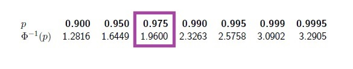

Figure 5.1: The table of standard normal quantiles used in recent exam papers for this module, with the $97.5\%$ quantile highlighted (which agrees with the quantile given by R).

The table gives the $97.5\%$ quantile as $\Phi^{-1}(0.975) \approx 1.96$. Symmetry of $N(0,1)$ implies that the $2.5\%$ quantile is $\Phi^{-1}(0.025) \approx -1.96$. This gives $c \approx 1.96$ and a rejection region
$$R = \{z : |z| \geq 1.96\}.$$
In other words, we can reject $H_{0}$ at the $5\%$ level if we observe $|Z| \geq 1.96$. Since we have an average quality of life $\overline{x} = 35$ in our sample, we get
$$|Z| = \left|\frac{35 - 30}{\sqrt{10^2/25}}\right| = 2.5 \in R$$
and therefore we reject $H_{0}$.

**Definition 5.5** Hypothesis tests based on a normally distributed $Z$ statistic are often called **z tests**.

This example required quite a lot of work. We had to determine the rejection region by manipulating probability expressions and the solving for some unknown constant. Rather than working with a rejection region, it is usually easier to simply work with p-values. An added advantage of p-values is that they can give us a better idea of how significant our results is, rather than just providing a binary reject or failure to reject decision.

**Definition 5.6** After observing our test statistic, the **p-value** is the smallest significance level at which this test statistic would lead us to reject the null hypothesis.

We sometimes think of a p-value as the observed level of significance. In practice, we tend to think of the p-value as the probability (under the null hypothesis) of obtaining a value of the test statistic **at least as extreme** as the value we **actually** observed.

**Example 5.4 (quality of life, continued)** We said that we would reject $H_{0}: \mu = 30$ if the test statistic $Z$ was far from zero. We observed a sample such that $Z = 2.5$. What was the probability of observing a test statistic so far from zero? We already calculated this to be
$$\begin{eqnarray*}
p = {\mathsf P}(|Z| \geq 2.5)
= 2\Phi(\leq -2.5)
\approx 1.2\%
\end{eqnarray*}$$
in Example 5.2. So our p-value is $p\approx 1.2\%$. This means, for example, that we would be willing to reject our null hypothesis at a significance level of $2\%$, but we would not be willing to reject at the $1\%$ significance level.

Clearly, a p-value gives us much more information than just a significance test. So why are p-values so controversial? Because people use them as an excuse to ignore practical significance. We observed a difference in average quality of life of $5$ points between patients who use the drug and those who don’t. We were able to conclude statistical significance, but practical significance requires further interpretation.

Is $5$ points on our quality of life scale a meaningful difference? Is it the difference between someone who is able to walk around normally and someone who is completely immobile? Or is it just the difference between someone who can compete in sports and someone who can only participate in less strenuous exercise? Is it a difference that would typically require significant surgery to achieve, or could it be achieved with simple lifestyle changes? Our p-value cannot answer these questions.

The p-value also focuses entirely on testing a single hypothesis, $H_{0}: \mu = 30$ in this example. Given that we observed $\overline{X} = 35$, we rejected $\mu = 30$. But can we also reject $\mu = 31$? What about $\mu = 40$? We need some way to write down a set of plausible values for $\mu$ that we are not willing to reject based on our observed data. This leads us to the idea of a confidence interval.

## 5.3 Confidence intervals

In the previous section, we considered a random variable $X$ with unknown ${\mathsf E}(X) = \mu$ and known $\text{var}(X) = \sigma^2$. To test
$$\begin{eqnarray*}
H_{0}: \mu = \mu_0 \quad \text{against} \quad H_{1}: \mu \neq \mu_0
\end{eqnarray*}$$
at the $5\%$ level, we defined a test statistic
$$Z = \frac{\overline{X} - \mu_0}{\sqrt{\sigma^2/n}} \stackrel{\text{approx.}}{\sim} N(0, 1).$$
We would reject $H_{0}$ if $|Z| \geq 1.96$ but would fail to reject $H_{0}$ if $|Z| < 1.96$.

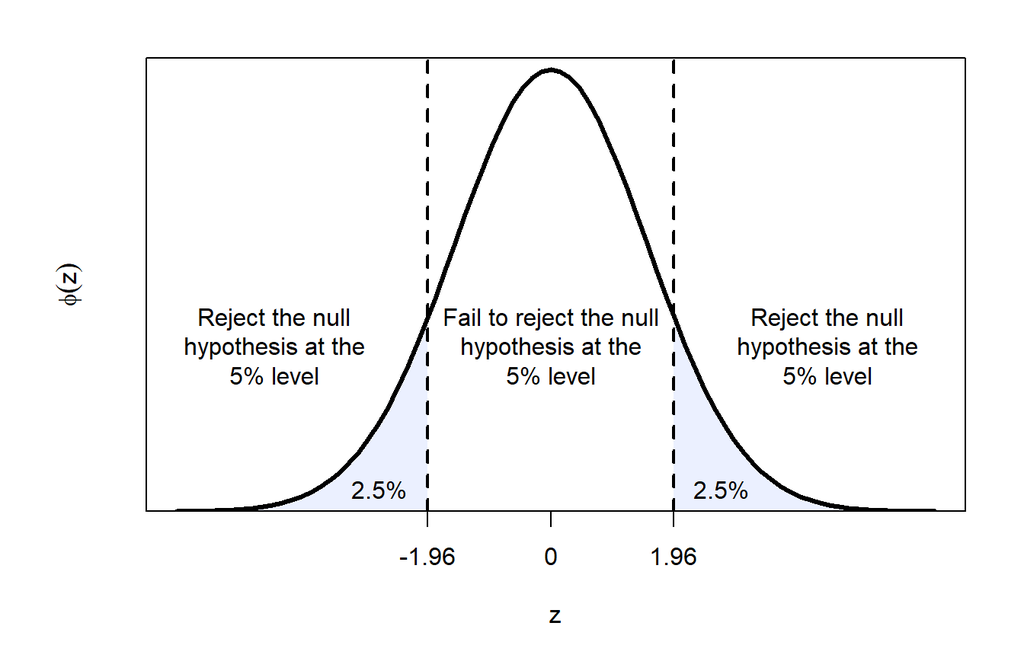

Figure 5.2: An illustration of our hypothesis testing procedure at the $5\%$ significance level. The function $\phi(z)$ is the density function of $N(0, 1)$. The null hypothesis is rejected when our test statistic $Z$ lies in the extreme tails of the distribution.

Our question is this: **Given an observed sample mean $\overline{x}$, which possible values of $\mu$ are we unable to reject at the $5\%$ significance level?** Based on Figure 5.2,
$$\begin{eqnarray*}
\text{fail to reject } H_0 & \quad \Leftrightarrow \quad & |z| < 1.96.
\end{eqnarray*}$$
So $|z| < 1.96$ is the condition on the test statistic $z$ that is equivalent to failing to reject $H_0$. But let’s express this instead as a condition on $\mu_0$:
$$\begin{eqnarray*}
|z| < 1.96 & \Leftrightarrow & -1.96 < z < 1.96\\
& \Leftrightarrow & -1.96 < \frac{\overline{x} - \mu_0}{\sqrt{\sigma^2/n}} < 1.96\\
& \Leftrightarrow & -1.96\sqrt{\frac{\sigma^2}{n}} < \overline{x} - \mu_0 < 1.96\sqrt{\frac{\sigma^2}{n}} \\
& \Leftrightarrow & - \overline{x}-1.96\sqrt{\frac{\sigma^2}{n}} < - \mu_0 < - \overline{x} + 1.96\sqrt{\frac{\sigma^2}{n}} \\
& \Leftrightarrow & \overline{x} + 1.96\sqrt{\frac{\sigma^2}{n}} > \mu_0 > \overline{x} - 1.96\sqrt{\frac{\sigma^2}{n}} \\
& \Leftrightarrow & \overline{x} - 1.96\sqrt{\frac{\sigma^2}{n}} < \mu_0 < \overline{x} + 1.96\sqrt{\frac{\sigma^2}{n}} \\
& \Leftrightarrow & \mu_0 \in \left(\overline{x} - 1.96\sqrt{\frac{\sigma^2}{n}} \;, \; \overline{x} + 1.96\sqrt{\frac{\sigma^2}{n}}\right).
\end{eqnarray*}$$

This interval is the set of all potential values of $\mu$ that we would be unable to reject. We could think of this as a set of “plausible values” for $\mu$. We can think of $\overline{x}$ as a **point estimate** for $\mu$ and we can think of this interval as an **interval estimate** for $\mu$.

We must notice that this interval depends on $\overline{x}$, which is a single realisation of a random statistic $\overline{X}$. This will vary from sample to sample, and therefore so will our interval estimate of $\mu$. So we ask another important question: **If we plan to take a random sample of size $n$, what is the probability that the resulting interval will contain the true value of $\mu$?**

Replacing the observed quantities $z$ and $\overline{x}$ with the random quantities $Z$ and $\overline{X}$ in the expressions above, setting $\mu_0 = \mu$, and working through the equivalences in reverse order, we easily see that we want the probability of
$$\begin{eqnarray*}
\mu \in \left(\overline{X} - 1.96\sqrt{\frac{\sigma^2}{n}} \;, \; \overline{X} + 1.96\sqrt{\frac{\sigma^2}{n}}\right) & \Leftrightarrow & -1.96 < \frac{\overline{X} - \mu}{\sqrt{\sigma^2/n}} < 1.96\\
&\Leftrightarrow & |Z| < 1.96
\end{eqnarray*}$$
where $Z \stackrel{\text{approx.}}{\sim} N(0, 1)$. Therefore, as we can see from Figure 5.2,
$$\begin{eqnarray*}
{\mathsf P}\left(\mu \in \left(\overline{X} - 1.96\sqrt{\frac{\sigma^2}{n}} \;, \; \overline{X} + 1.96\sqrt{\frac{\sigma^2}{n}}\right)\right) = {\mathsf P}( |Z| < 1.96 ) \approx 95\%.
\end{eqnarray*}$$

**Definition 5.7** Consider a random interval $(U, V)$ calculated from a random sample. This interval is a **$100(1-\alpha)\%$-confidence interval** for a parameter $\theta$ if
$$P\left(\theta \in (U, V)\right) \geq 1 - \alpha$$
for $\alpha \in (0,1)$.

So our random interval above is an approximate $95\%$-confidence interval for the parameter $\mu$. We can easily generalise this, as we will see in the next theorem.

**Definition 5.8** For any $\gamma \in (0,1)$, the $(1 - \gamma)$ **quantile** of $Z \sim N(0, 1)$ is the unique number $z_{\gamma}$ such that
$$P(Z \leq z_{\gamma}) = \Phi(z_{\gamma}) = 1 - \gamma.$$
Equivalently, $z_{\gamma} = \Phi^{-1}(1-\gamma)$.

**Theorem 5.3** Let $X_{1}, \ldots, X_{n}$ be an IID random sample from a **normal distribution** with **known** variance $\sigma^2$. Then
$$\left(\overline{X} - z_{\alpha/2} \sqrt{\frac{\sigma^2}{n}} \;\;, \;\; \overline{X} + z_{\alpha/2}\sqrt{\frac{\sigma^2 }{n}} \right)$$
is a $100(1-\alpha)\%$-confidence interval for the population mean $\mu$. If we **can’t** assume that the sample comes from a normal distribution but the sample size $n$ is large, this interval is an **approximate** $100(1-\alpha)\%$-confidence interval for $\mu$.

When applying this theorem in practice, we often **don’t** know $\sigma^2$. However, we might reasonably estimate it from our data if our sample size is **large** and assume $\sigma^2 = s^2$. This means that, as long as the sample size is large, we have a way to calculate an approximate confidence interval, **no matter what the underlying distribution of our sample is** (it does not matter whether the distribution is known or not). Notice also that in cases where our sample **is** assumed to be from a normal distribution, the theorem applies for **any** sample size (it does not need to be large).

*Proof.* The proof of this theorem is left as an exercise. Just follow the reasoning outlined above, replacing $1.96$ with the relevant quantile. In the case that the sample comes from a normal distribution, $X_{1}, \ldots, X_{n} \sim N(\mu, \sigma^2)$, we simply replace every “$\approx$” with “$=$” because the approximate sampling distribution suggested by the CLT will actually be the exact sampling distribution of $Z$.

**Example 5.5 (quality of life, continued)** In our example, we had a known variance $\sigma^2 = 100$ and sample size $n = 25$. Therefore a $95\%$-confidence interval for the unknown mean $\mu$ would be the random interval
$$\left(\overline{X} - 1.96\sqrt{\frac{\sigma^2}{n}} \;, \; \overline{X} + 1.96\sqrt{\frac{\sigma^2}{n}}\right) \approx (\overline{X} - 3.92 \;,\; \overline{X} + 3.92)$$
where we have used $\alpha = 5\%$ and $z_{\alpha/2}\approx 1.96$. This **random** interval has a $95\%$ chance of containing the true value of $\mu$, in the sense that if we were to observe a thousand samples (and thus observed a thousand different sample means, $\overline{x}$) then we would anticipate around $950$ of the intervals
$$(\overline{x} - 3.92 \;,\; \overline{x} + 3.92)$$
to contain $\mu$. In reality, we usually only observe one sample. Our observed sample gave us $\overline{x} = 35$ and therefore
$$(\overline{x} - 3.92 \;,\; \overline{x} + 3.92) = (31.08 \;,\; 38.92).$$

So, if someone claims that the average quality of life of COPD patients on the drug is $40$, we can reject that claim at the $5\%$ significance level since $40$ does not lie in the interval. In fact, we can reject the hypothesis $\mu = \mu_{0}$ for any $\mu_0$ outside the interval.

If we want a $99\%$ confidence interval, we can use R (or a table) to get the necessary quantile:

```r
alpha <- 0.01
qnorm(p = 1 - alpha/2, mean = 0, sd = 1)
```

```
## [1] 2.575829
```

This gives $z_{0.01/2} \approx 2.58$. Then our interval is
$$(29.84 \;,\; 40.16)$$
and we see that, at the $1\%$ significance level, our hypothesis test cannot reject either $\mu = 40$ or $\mu = 30$ because both lie inside the interval.

This example demonstrates why we prefer to present a confidence interval rather than the “reject or fail to reject” conclusion of a hypothesis test. At a given significance level, the confidence interval gives us the conclusions of all possible hypothesis tests at once.

[^1]: For example, see the EQ-5D thermometer (https://euroqol.org/wp-content/uploads/2019/10/EQ-5D-3L-User-Guide_version-6.0.pdf).
[^2]: The statement given here is actually just a **consequence** of the CLT. The precise statement of the CLT would require concepts beyond the scope of this module, such as convergence of sequences of random variables. However, for the practical purposes of this module, this statement is sufficient.